# Regresion

```r
# Se cargan las librerías empleadas en la tarea.
library(GGally) # carga el método ggpairs.
library(Metrics) # carga la métrica MSE.
library(caTools) # carga el método sample.split.
```

# Tarea 3.

# Regresión lineal

Análisis del Problema

El desempeño de un automóvil se puede medir de diferentes formas. Algunas comunes son la cantidad de caballos de fuerza y el rendimiento del mismo, que se puede resumir en cuantas millas puede recorrer el automóvil por cada galón de combustible que consume. Para los clientes, potenciales compradores de un automóvil, este rendimiento es importante pues puede ayudar a tomar una decisión con respecto a cuál automóvil comprar (si, por ejemplo, el cliente quiere un auto que rinda por muchas millas y pueda economizar en la compra de combustible).

Desde este punto de vista, tanto a clientes como a fabricantes de automóviles, les conviene entender cuál es la relación entre diferentes características del automóvil y su rendimiento, pues el conocer estas relaciones les puede ayudar a inferir cuál va a ser la eficiencia del vehículo a partir de ver los valores de otras características. Para fabricantes, puede ser importante conocer estas relaciones para saber cómo hacer cada modelo más eficiente con respecto al anterior.

Entendimiento de los Datos

Con el fin de analizar y tratar de estimar las millas por galón de diferentes modelos de automóviles, se trabajó con un conjunto de datos que contiene 398 observaciones y 9 variables:

- mpg (millas por galón): numérica, con un rango de 9 a 46.60.
- cyl (cilindraje): categórica ordinal, con valores posibles de 3, 4, 5, 6 y 8.
- disp (desplazamiento): numérica, con un rango de 68 a 455.
- hp (caballos de fuerza): numérica, con un rango de 46 a 230 y 6 valores faltantes.
- weight (peso): numérica, con un rango de 1613 a 5140.
- acc (aceleración): numérica, con un rango de 8 a 24.80.
- model year (año): categórica, con 13 valores diferentes representando el año del automóvil.
- origin (origen): categórica, 3 valores posibles: 1, 2, 3.
- model name (nombre del modelo): categórica, con 305 posibles valores.

# Ejercicios

1. Cargue el archivo auto-mpg_g.csv en una variable

```r
# Se carga el dataset en la variable autos_data.
autos_data <- read.csv("auto-mpg_g.csv", header = TRUE)

# Se valida la carga correcta de los datos.
head(autos_data)
```

|  | mpg | cyl | disp | hp | weight | acc | model.year | origin | model.name |
| --- | --- | --- | --- | --- | --- | --- | --- | --- | --- |
| 1 | 18 | 8 | 307 | 130 | 3504 | 12 | 70 | 1 | chevrolet chevelle malibu |
| 2 | 15 | 8 | 350 | 165 | 3693 | 12 | 70 | 1 | buick skylark 320 |
| 3 | 18 | 8 | 318 | 150 | 3436 | 11 | 70 | 1 | plymouth satellite |
| 4 | 16 | 8 | 304 | 150 | 3433 | 12 | 70 | 1 | amc rebel sst |
| 5 | 17 | 8 | 302 | 140 | 3449 | 11 | 70 | 1 | ford torino |
| 6 | 15 | 8 | 429 | 198 | 4341 | 10 | 70 | 1 | ford galaxie 500 |

```r
# Se observa la estructura de los datos.
str(autos_data)
```

```
## 'data.frame':    398 obs. of  9 variables:
##  $ mpg       : int  18 15 18 16 17 15 14 14 14 15 ...
##  $ cyl       : int  8 8 8 8 8 8 8 8 8 8 ...
##  $ disp      : int  307 350 318 304 302 429 454 440 455 390 ...
##  $ hp        : int  130 165 150 150 140 198 220 215 225 190 ...
##  $ weight    : int  3504 3693 3436 3433 3449 4341 4354 4312 4425 3850 ...
##  $ acc       : int  12 12 11 12 11 10 9 9 10 9 ...
##  $ model.year: int  70 70 70 70 70 70 70 70 70 70 ...
##  $ origin    : int  1 1 1 1 1 1 1 1 1 1 ...
##  $ model.name: Factor w/ 305 levels " amc ambassador brougham",..: 50 37 232 15 162 142 55 224 242 2 ...
```

```r
# Se observan algunos detalles de los mismos.
summary(autos_data)
```

```
##       mpg             cyl             disp             hp
##  Min.   : 9.00   Min.   :3.000   Min.   : 68.0   Min.   :  0.0
##  1st Qu.:18.00   1st Qu.:4.000   1st Qu.:104.2   1st Qu.: 75.0
##  Median :23.00   Median :4.000   Median :148.5   Median : 92.0
##  Mean   :23.56   Mean   :5.455   Mean   :193.4   Mean   :102.9
##  3rd Qu.:29.00   3rd Qu.:8.000   3rd Qu.:262.0   3rd Qu.:125.0
##  Max.   :47.00   Max.   :8.000   Max.   :455.0   Max.   :230.0
##
##      weight          acc          model.year        origin
##  Min.   :1613   Min.   : 8.00   Min.   :70.00   Min.   :1.000
##  1st Qu.:2224   1st Qu.:14.00   1st Qu.:73.00   1st Qu.:1.000
##  Median :2804   Median :16.00   Median :76.00   Median :1.000
##  Mean   :2970   Mean   :15.71   Mean   :76.01   Mean   :1.573
##  3rd Qu.:3608   3rd Qu.:17.00   3rd Qu.:79.00   3rd Qu.:2.000
##  Max.   :5140   Max.   :25.00   Max.   :82.00   Max.   :3.000
##
##            model.name
##   ford pinto    :  6
##   amc matador   :  5
##   ford maverick :  5
##   toyota corolla:  5
##   amc gremlin   :  4
##   amc hornet    :  4
##  (Other)        :369
```

2. Utilizando Ggpairs cree un gráfico de los atributos del dataset, observe las correlaciones entre atributos

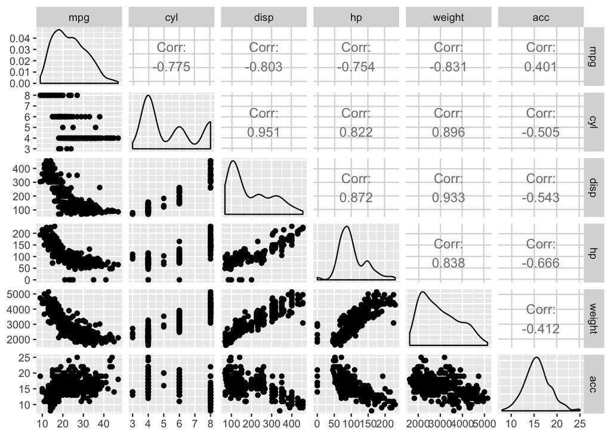

```r
# Se grafica las correlaciones entre variables (como parte del EDA y previo a limpiar los datos).
# Se omiten los datos almacenados en las variables "model.year", "origin" y "model.name" debido
# a que estas son variables categóricas.
ggpairs(autos_data[, c("mpg", "cyl", "disp", "hp", "weight", "acc")])
```

3. Separe los datos en 2 conjuntos, uno de entrenamiento y otro de pruebas. Normalmente se trabaja utilizando un 70-80% de los datos para entrenamiento y el resto para pruebas.

Recuerde fijar una semilla para que el documento sea reproducible.

Pista: https://www.rdocumentation.org/packages/caTools/versions/1.17.1/topics/sample.split

```r
# Se setea la semilla.
set.seed(1)

# Se genera el vector lógico para separar los dataframes de entrenamiento y pruebas.
data_split <- sample.split(autos_data, SplitRatio = 0.8)

# Se carga el dataset con los datos de entrenamiento.
autos_train_data <- subset(autos_data, data_split == TRUE)

# Se carga el dataset con los datos de prueba.
autos_test_data <- subset(autos_data, data_split == FALSE)
```

4. Cree un modelo de regresion lineal utilizando el atributo mpg como la variable objetivo y en base a las correlaciones observadas en el gráfico del punto 2 escoja al menos dos atributos para usarlos como variables predictoras para el modelo.

Pista: https://www.rdocumentation.org/packages/lessR/versions/1.9.8/topics/reg

Nota: Al crear el modelo utilice el conjunto de datos de entrenamiento definido en el punto 3.

```r
# Se crea un modelo de regresión lineal empleando como variables predictorias a "disp" y "weight".
autos_model <- lm(mpg ~ weight + disp, autos_train_data)
```

5. Realice predicciones utilizando el conjunto de pruebas y evalue el resultado con la métrica MSE.

Pista: https://www.rdocumentation.org/packages/mltools/versions/0.3.5/topics/mse

```r
# Se realiza la predicción de los datos de prueba.
mpg_prediction <- predict(autos_model, autos_test_data)

# Se calcula el error cuadrático medio (mean-square error).
autos_mse <- mse(actual = autos_test_data$mpg, predicted = mpg_prediction)
autos_mse
```

```
## [1] 17.87387
```

6. Opcional

6.a Pruebe varios modelos que utilicen diferentes variables y comparar los resultados obtenidos

```r
# Se va a probar la siguiente fórmula (igualmente sin preprocesado ni normalización)
# mpg ~ disp + cyl + weight + hp

# Se crea un modelo de regresión lineal empleando como variables predictorias a "disp", "cyl", "weight" y "hp".
autos_model2 <- lm(mpg ~ disp + cyl + weight + hp, autos_train_data)

# Se realiza la predicción de los datos de prueba.
mpg_prediction2 <- predict(autos_model2, autos_test_data)

# Se calcula el error cuadrático medio (mean-square error).
autos_mse2 <- mse(actual = autos_test_data$mpg, predicted = mpg_prediction2)
autos_mse2
```

```
## [1] 17.79894
```

6.b Investigar como implementar en R las técnicas de preprocesado y normalización vistas en clase y aplicarlas a los datos antes de pasarlos al modelo.

```r
# Procesar los 6 valores faltantes en "hp".
#
# Fuentes de los datos faltantes:
#
# https://en.wikipedia.org/wiki/Ford_Pinto
# https://en.wikipedia.org/wiki/Ford_Maverick_(Americas)
# https://www.automobile-catalog.com/car/1980/27095/renault_5_le_car.html
# https://www.caranddriver.com/reviews/a15142429/1980-ford-mustang-cobra-review/
# https://www.conceptcarz.com/z25395/renault-18i.aspx
# https://www.automobile-catalog.com/make/amc/concord/concord_2-door_dl/1982.html
#
autos_data[autos_data$hp == 0, ]
```

|  | mpg | cyl | disp | hp | weight | acc | model.year | origin | model.name |
| --- | --- | --- | --- | --- | --- | --- | --- | --- | --- |
| 393 | 25 | 4 | 98 | 0 | 2046 | 19 | 71 | 1 | ford pinto |
| 394 | 21 | 6 | 200 | 0 | 2875 | 17 | 74 | 1 | ford maverick |
| 395 | 41 | 4 | 85 | 0 | 1835 | 17 | 80 | 2 | renault lecar deluxe |
| 396 | 24 | 4 | 140 | 0 | 2905 | 14 | 80 | 1 | ford mustang cobra |
| 397 | 35 | 4 | 100 | 0 | 2320 | 16 | 81 | 2 | renault 18i |
| 398 | 23 | 4 | 151 | 0 | 3035 | 21 | 82 | 1 | amc concord dl |

```r
missing_hp <- autos_data[autos_data$hp == 0, ]
researched_names_missing <- c(" ford pinto", " ford maverick", " renault lecar deluxe",
                              " ford mustang cobra", " renault 18i", " amc concord dl")
researched_hp_missing <- c(75L, 120L, 51L, 132L, 81L, 82L)

# Se duplica el dataset (para poseer trazabilidad) y se cambia la variable "model.name" a character.
autos_data_no_missing <- autos_data
autos_data_no_missing$model.name <- as.character(autos_data_no_missing$model.name)

# Se itera sobre cada uno de los valores por agregar.
for (index in seq_along(researched_names_missing)) {
  name <- researched_names_missing[index]
  hp <- researched_hp_missing[index]
  year <- missing_hp[index, ]$model.year # Existen varios modelos con el mismo nombre por distintos años.
  autos_data_no_missing[(name == autos_data_no_missing$model.name) &
                          (year == autos_data_no_missing$model.year), ]$hp <- hp
}

# Se valida que los valores en el nuevo dataset se hayan cambiado correctamente
# (se usa la comparación con el dataset original para mayor facilidad).
autos_data_no_missing[autos_data$hp == 0, ]
```

|  | mpg | cyl | disp | hp | weight | acc | model.year | origin | model.name |
| --- | --- | --- | --- | --- | --- | --- | --- | --- | --- |
| 393 | 25 | 4 | 98 | 75 | 2046 | 19 | 71 | 1 | ford pinto |
| 394 | 21 | 6 | 200 | 120 | 2875 | 17 | 74 | 1 | ford maverick |
| 395 | 41 | 4 | 85 | 51 | 1835 | 17 | 80 | 2 | renault lecar deluxe |
| 396 | 24 | 4 | 140 | 132 | 2905 | 14 | 80 | 1 | ford mustang cobra |
| 397 | 35 | 4 | 100 | 81 | 2320 | 16 | 81 | 2 | renault 18i |
| 398 | 23 | 4 | 151 | 82 | 3035 | 21 | 82 | 1 | amc concord dl |

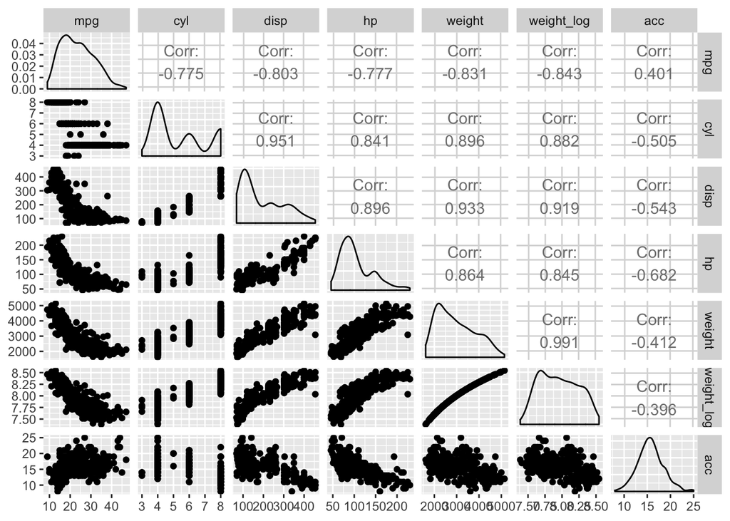

```r
# Normalizar o estandarizar las variables para que calcen en una distribución normal.
autos_data_norm <- autos_data_no_missing
autos_data_norm$weight_log <- log(autos_data_norm$weight)

# Se grafica las correlaciones entre variables.
ggpairs(autos_data_norm[, c("mpg", "cyl", "disp", "hp", "weight", "weight_log", "acc")])
```

```r
# Se genera el vector lógico para separar los dataframes de entrenamiento y pruebas.
data_split_final <- sample.split(autos_data_norm, SplitRatio = 0.8)

# Se carga el dataset con los datos de entrenamiento.
autos_train_data_final <- subset(autos_data_norm, data_split == TRUE)

# Se carga el dataset con los datos de prueba.
autos_test_data_final <- subset(autos_data_norm, data_split == FALSE)

# Se seleccionan las variables para usarlas como variables predictorias.
# Se crea un modelo de regresión lineal.
# Se ajustan los parámetros de la función.
autos_model_final <- lm(mpg ~ poly(weight_log, 2) + poly(hp, 3) + poly(disp, 3) + poly(acc, 5),
                        autos_train_data_final)

# Se realiza la predicción de los datos de prueba.
mpg_prediction_final <- predict(autos_model_final, autos_test_data_final)

# Se calcula el error cuadrático medio (mean-square error).
autos_mse_final <- mse(actual = autos_test_data_final$mpg, predicted = mpg_prediction_final)
autos_mse_final
```

```
## [1] 14.53498
```

Se logró mejorar el MSE del modelo de un 17.8738692 a un MSE final de 14.5349769.